# Modal Clustering

## Loading Library and Packages

```r
library(meanShiftR)
library(mvtnorm)
library(here)
library(dplyr)
```

```r
library(ggplot2)
```

```r
dir <- here()
```

If this doesn’t work, can also use getwd() below which gets the current work directory.

```r
dir <- getwd()
```

```r
dir.sep <- "/"
echo <- F # controls whether outputs sequences during optimization
source(paste(dir, "function_packages", "kernel-density-estimation-functions.R", sep = dir.sep))
source(paste(dir, "function_packages", "gaussian-mixture-model-functions.R", sep = dir.sep))
source(paste(dir, "function_packages", "density-optimizing-functions.R", sep = dir.sep))
source(paste(dir, "function_packages", "gsl-functions-6-8-2018.R", sep = dir.sep))
```

## Importing Data

### Olive Oil dataset

Olive oil data has 572 observations with 8 variables and 9 distinct groups.

```r
data.filename <- "olive.R"
data.pathname <- paste(dir, "data", data.filename, sep = dir.sep)
source(data.pathname)
```

A glimpse of olive oil data. columns represent variables and rows represent observations.

```r
oil.data <- X # save the matrix as 'oil.data'
oil.group.id <- group.id # save the id as 'oil.group.id'
sphered.oil <- sphere(oil.data)
head(X)
```

```
##      [,1] [,2] [,3] [,4] [,5] [,6] [,7] [,8]
## [1,] 1075   75  226 7823  672   36   60   29
## [2,] 1088   73  224 7709  781   31   61   29
## [3,]  911   54  246 8113  549   31   63   29
## [4,]  966   57  240 7952  619   50   78   35
## [5,] 1051   67  259 7771  672   50   80   46
## [6,]  911   49  268 7924  678   51   70   44
```

Corresponding group id for olive oil data.

```r
oil.group.id
```

```
##   [1] 1 1 1 1 1 1 1 1 1 1 1 1 1 1 1 1 1 1 1 1 1 1 1 1 1 2 2 2 2 2 2 2 2 2 2
##  [36] 2 2 2 2 2 2 2 2 2 2 2 2 2 2 2 2 2 2 2 2 2 2 2 2 2 2 2 2 2 2 2 2 2 2 2
##  [71] 2 2 2 2 2 2 2 2 2 2 2 3 3 3 3 3 3 3 3 3 3 3 3 3 3 3 3 3 3 3 3 3 3 3 3
## [106] 3 3 3 3 3 3 3 3 3 3 3 3 3 3 3 3 3 3 3 3 3 3 3 3 3 3 3 3 3 3 3 3 3 3 3
## [141] 3 3 3 3 3 3 3 3 3 3 3 3 3 3 3 3 3 3 3 3 3 3 3 3 3 3 3 3 3 3 3 3 3 3 3
## [176] 3 3 3 3 3 3 3 3 3 3 3 3 3 3 3 3 3 3 3 3 3 3 3 3 3 3 3 3 3 3 3 3 3 3 3
## [211] 3 3 3 3 3 3 3 3 3 3 3 3 3 3 3 3 3 3 3 3 3 3 3 3 3 3 3 3 3 3 3 3 3 3 3
## [246] 3 3 3 3 3 3 3 3 3 3 3 3 4 4 4 4 4 4 4 4 4 4 4 4 4 4 4 4 4 4 4 4 4 4 4
## [281] 4 4 4 4 4 4 4 4 4 4 4 4 4 3 3 3 3 3 3 3 3 3 3 3 3 3 3 3 3 3 3 3 3 3 3
## [316] 3 3 3 3 3 3 3 3 5 5 5 5 5 5 5 5 5 5 5 6 6 6 6 6 6 5 5 5 5 5 5 5 5 5 5
## [351] 5 5 5 5 5 5 5 5 5 5 5 5 5 5 5 5 5 5 5 5 6 6 6 6 6 6 6 6 6 6 6 6 6 6 6
## [386] 5 5 5 5 5 5 5 5 5 5 5 5 5 5 5 5 5 5 5 5 5 5 5 5 6 6 6 6 6 6 6 6 6 6 6
## [421] 6 9 9 9 9 9 9 9 9 9 9 9 9 9 9 9 9 9 9 9 9 9 9 9 9 9 9 9 9 9 9 9 9 9 9
## [456] 9 9 9 9 9 9 9 9 9 9 9 9 9 9 9 9 9 7 7 7 7 7 7 7 7 7 7 7 7 7 7 7 7 7 7
## [491] 7 7 7 7 7 7 7 7 7 7 7 7 7 7 7 7 7 7 7 7 7 7 7 7 7 7 7 7 7 7 7 7 8 8 8
## [526] 8 8 8 8 8 8 8 8 8 8 8 8 8 8 8 8 8 8 8 8 8 8 8 8 8 8 8 8 8 8 8 8 8 8 8
## [561] 8 8 8 8 8 8 8 8 8 8 8 8
```

### Wine dataset

Wine data has 178 observations with 13 variables and 3 distinct groups. Details of the dataset can be found at: https://rdrr.io/cran/rattle.data/man/wine.html

```r
data(wine, package='rattle')
wine.matrix <- data.matrix(wine) # transform dataframe into matrix
wine.data <- wine.matrix[,-1] # data without group id
wine.group.id <- wine.matrix[,1] # group id
sphered.wine <- sphere(wine.data)
```

A glimpse of wine data.

```r
head(wine.matrix)
```

```
##      Type Alcohol Malic  Ash Alcalinity Magnesium Phenols Flavanoids
## [1,]    1   14.23  1.71 2.43       15.6       127    2.80       3.06
## [2,]    1   13.20  1.78 2.14       11.2       100    2.65       2.76
## [3,]    1   13.16  2.36 2.67       18.6       101    2.80       3.24
## [4,]    1   14.37  1.95 2.50       16.8       113    3.85       3.49
## [5,]    1   13.24  2.59 2.87       21.0       118    2.80       2.69
## [6,]    1   14.20  1.76 2.45       15.2       112    3.27       3.39
##      Nonflavanoids Proanthocyanins Color  Hue Dilution Proline
## [1,]          0.28            2.29  5.64 1.04     3.92    1065
## [2,]          0.26            1.28  4.38 1.05     3.40    1050
## [3,]          0.30            2.81  5.68 1.03     3.17    1185
## [4,]          0.24            2.18  7.80 0.86     3.45    1480
## [5,]          0.39            1.82  4.32 1.04     2.93     735
## [6,]          0.34            1.97  6.75 1.05     2.85    1450
```

Corresponding group id for wine data

```r
wine.group.id
```

```
##   [1] 1 1 1 1 1 1 1 1 1 1 1 1 1 1 1 1 1 1 1 1 1 1 1 1 1 1 1 1 1 1 1 1 1 1 1
##  [36] 1 1 1 1 1 1 1 1 1 1 1 1 1 1 1 1 1 1 1 1 1 1 1 1 2 2 2 2 2 2 2 2 2 2 2
##  [71] 2 2 2 2 2 2 2 2 2 2 2 2 2 2 2 2 2 2 2 2 2 2 2 2 2 2 2 2 2 2 2 2 2 2 2
## [106] 2 2 2 2 2 2 2 2 2 2 2 2 2 2 2 2 2 2 2 2 2 2 2 2 2 3 3 3 3 3 3 3 3 3 3
## [141] 3 3 3 3 3 3 3 3 3 3 3 3 3 3 3 3 3 3 3 3 3 3 3 3 3 3 3 3 3 3 3 3 3 3 3
## [176] 3 3 3
```

### 2d Gaussian clusters

Synthetic 2d dataset with 5000 observations and 15 distinct groups. Each group corresponds to a Gaussian cluster. The data is retrieved from: http://cs.joensuu.fi/sipu/datasets/

```r
dat <- read.csv('data/s-originals/s1.csv', header = T, sep = "")
colnames(dat) <- c('f1', 'f2', 'group_id')
```

Visualization of the dataset:

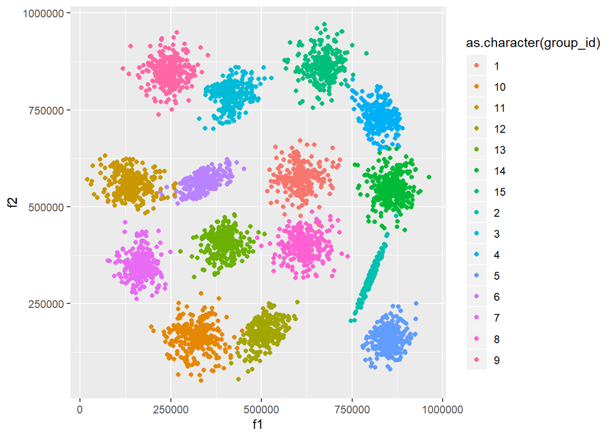

```r
ggplot(dat, aes(x = f1, y = f2, label = group_id)) +
  geom_point(aes(colour = as.character(group_id)))
```

For the sake of demonstration, we took a sample of 500 observations from the dataset

```r
set.seed(1234)
dat.sample <- sample_n(dat, 500)
dat.sample <- dat.sample[order(dat.sample$group_id),] # order based on group id
gaussian.2d <- as.matrix(dat.sample[,c('f1','f2')])
sphered.gaussian.2d <- sphere(gaussian.2d)
```

Visualization of the sample:

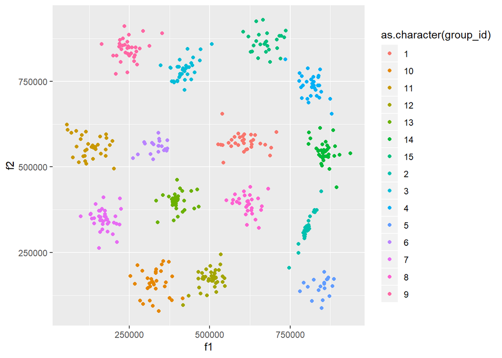

```r
ggplot(dat.sample, aes(x = f1, y = f2, label = group_id)) +
  geom_point(aes(colour = as.character(group_id)))
```

## Kernel Density Estimation

The first approach is by kernel density estimation. The idea is that we first estimate the density function of the datasets by kernel density estimation. By default we use gaussian kernel as our kernel function. After we have the estimated density function, we want to perform optimization on each data point. Basically we start with each data point and shift it uphill until it converges. Then the set of all points that converge to the same mode will correspond to one estimated cluster.

### **1. Olive Oil**

#### Bandwidth Selection

We first sphere the dataset and pick the bandwidth by cross-validation

```r
trial.hs <- c(0.05, 0.1, 0.15, 0.2, 0.3, 0.4, 0.6, 0.8, 1.0, 1.5, 2.0)
cv.search.out <- cv.search(sphered.oil, trial.hs)
h.oil <- cv.search.out$opt.smopar
```

```r
h.oil
```

```
## [1] 0.2287662
```

#### Kernel Density Estimator

Fit kernel density estimation on oil data

```r
density.oil <- make.gaussian.kernel.density.estimate(sphered.oil, h.oil)
```

#### Numerical Optimization

Perform numerical optimization on each data point

```r
optim.out.filename <- "/optimizing_result/oil-density-optima.R"
optim.out.pathname <- paste(dir, optim.out.filename, sep = "\\")
```

```r
gradient <- make.kde.gradient(sphered.oil, h.oil)
optimize.density(sphered.oil, density.oil, optim.out.pathname, gradient = gradient, echo = echo)
```

Read optimization result. 0 means all points converge.

```r
optima <- read.optim(sphered.oil, optim.out.pathname)
```

```
## [1] 0
```

#### Cluster Local Maxima

```r
clust <- hclust(dist(optima), method = "ward.D2")
clust$height
```

```
##   [1] 1.593633e-07 3.096232e-07 3.500207e-07 4.404311e-07 9.316055e-07
##   [6] 1.089246e-06 1.200900e-06 2.072682e-06 2.125820e-06 2.432126e-06
##  [11] 2.494811e-06 2.633229e-06 2.980080e-06 3.572043e-06 3.639627e-06
##  [16] 3.706452e-06 3.987042e-06 4.280002e-06 4.387749e-06 4.486867e-06
##  [21] 4.814521e-06 7.177568e-06 7.711203e-06 8.018707e-06 8.306188e-06
##  [26] 8.756061e-06 9.008129e-06 9.016274e-06 9.171425e-06 9.624397e-06
##  [31] 1.116317e-05 1.241234e-05 1.265498e-05 1.276150e-05 1.482564e-05
##  [36] 1.493561e-05 1.501013e-05 1.585827e-05 1.800896e-05 1.813333e-05
##  [41] 2.168551e-05 2.538463e-05 2.960414e-05 2.980550e-05 3.223925e-05
##  [46] 4.033639e-05 6.953375e-05 8.847683e-05 1.500374e-01 2.446308e-01
##  [51] 2.779288e-01 3.372521e-01 4.029786e-01 4.073558e-01 4.199983e-01
##  [56] 5.079600e-01 5.237530e-01 5.443374e-01 5.568692e-01 5.587108e-01
##  [61] 5.591257e-01 5.602887e-01 5.648123e-01 5.778447e-01 5.851664e-01
##  [66] 5.866646e-01 5.975467e-01 6.243671e-01 6.245063e-01 6.295472e-01
##  [71] 6.308466e-01 6.350474e-01 6.354224e-01 6.367284e-01 6.445653e-01
```

[output cut: 100 more lines]

These are merge distances based on hierarchical clustering of the local maximas. There is a “jump” between 48 and 49 which suggests that there are 572-48=524 distinct groups, which is apparently not true.

```r
estimated.oil.group.id <- cutree(clust, 9)
```

```r
table(data.frame(true.id = oil.group.id, estimated.id = estimated.oil.group.id))
```

```
##        estimated.id
## true.id   1   2   3   4   5   6   7   8   9
##       1  23   2   0   0   0   0   0   0   0
##       2   6   0  44   4   1   1   0   0   0
##       3   2   1   4   2 194   1   2   0   0
##       4  21   1  10   1   2   0   1   0   0
##       5   0   4   0   0   0   1   3  57   0
##       6   0   0   0   0   0   0   0  33   0
##       7   0  33   0   1   0  13   0   1   2
##       8   0   1   0   6   0   0   2   0  41
##       9   0   0   0   0   0  51   0   0   0
```

```r
rand.index(oil.group.id, estimated.oil.group.id)
```

```
## [1] 0.7912494
```

### **2. Wine**

We repeat the procedure above for wine dataset.

#### Bandwidth Selection

```r
trial.hs <- c(0.05, 0.1, 0.15, 0.2, 0.3, 0.4, 0.6, 0.8, 1.0, 1.5, 2.0)
cv.search.out <- cv.search(sphered.wine, trial.hs)
h.wine <- cv.search.out$opt.smopar
```

```r
h.wine
```

```
## [1] 0.7035063
```

#### Kernel Density Estimator

```r
density.wine <- make.gaussian.kernel.density.estimate(sphered.wine, h.wine)
```

#### Numerical Optimization

```r
optim.out.filename <- "/optimizing_result/wine-density-optima.R"
optim.out.pathname <- paste(dir, optim.out.filename, sep = "\\")
```

```r
gradient <- make.kde.gradient(sphered.wine, h.wine)
optimize.density(sphered.wine, density.wine, optim.out.pathname, gradient = gradient, echo = echo)
```

```r
optima <- read.optim(sphered.wine, optim.out.pathname)
```

```
## [1] 0
```

#### Cluster Local Maxima

```r
clust <- hclust(dist(optima), method = "ward.D2")
clust$height
```

```
##   [1]  0.7989619  1.2502796  1.2853250  1.3063126  1.3906310  1.4016275
##   [7]  1.5108360  1.5285786  1.5888489  1.6825369  1.7700296  1.7739035
##  [13]  1.8213001  1.8313474  1.8675225  1.8765557  1.9003476  1.9084073
##  [19]  1.9512099  1.9694001  1.9758139  2.0778779  2.0805668  2.0809820
##  [25]  2.0862383  2.1440123  2.1585582  2.1587881  2.1838661  2.1941844
##  [31]  2.1965938  2.2178516  2.2493483  2.2966232  2.2991585  2.3014979
##  [37]  2.3088487  2.3288649  2.3597665  2.3624177  2.3645609  2.4168241
##  [43]  2.4555205  2.4660256  2.4688631  2.4747004  2.5217321  2.5668566
##  [49]  2.5697544  2.5720457  2.5931810  2.5951409  2.6032420  2.6111926
##  [55]  2.6147827  2.6187356  2.6216262  2.6263913  2.6374741  2.6477096
##  [61]  2.6512227  2.6604048  2.6832075  2.7111777  2.7471886  2.7849384
##  [67]  2.8283811  2.8316111  2.8345464  2.8395716  2.8430892  2.8478459
##  [73]  2.8709486  2.8793964  2.8986391  2.9125604  2.9275581  2.9650000
##  [79]  2.9700756  2.9726992  2.9931351  2.9972790  3.0369764  3.0397634
##  [85]  3.0625046  3.0864227  3.1036622  3.1111314  3.1454515  3.1462877
##  [91]  3.1746718  3.1765505  3.1805251  3.1893324  3.2218859  3.2260070
##  [97]  3.2475069  3.2514618  3.4813040  3.5090469  3.5107028  3.5465126
## [103]  3.5907066  3.5988802  3.6454660  3.7012660  3.7112074  3.7765042
## [109]  3.8248677  3.8829523  3.9152659  3.9554838  3.9829390  4.0843665
## [115]  4.1523970  4.2249119  4.2804751  4.3438618  4.4808882  4.4918757
## [121]  4.5017728  4.5766561  4.6313428  4.6708403  4.6891054  4.7190669
## [127]  4.7392040  4.7523372  4.7930325  4.8363702  4.8608932  4.9291653
## [133]  4.9563708  4.9929688  5.1026965  5.1148063  5.1372773  5.1769765
## [139]  5.1893111  5.2135128  5.2550688  5.2838058  5.2931445  5.3165853
## [145]  5.4271551  5.9639346  6.0309195  6.2763082  6.2827987  6.4244877
## [151]  6.4952124  6.7085423  6.8939868  7.0159099  7.0210455  7.1744127
## [157]  7.3986275  7.5006603  7.8974931  7.9127176  8.2168260  8.3816097
## [163]  8.8900868  9.1546363  9.4414025  9.5397202  9.6666301  9.9040177
## [169] 10.2341305 11.4769690 12.0769852 12.7012931 12.8839006 13.7114024
## [175] 14.2208063 15.7943008 16.3284035
```

The merge distances are all pretty large, which suggest there are 178 distinct groups, i.e. every observation forms a group itself.

```r
estimated.wine.group.id <- cutree(clust, 3)
```

```r
table(data.frame(true.id = wine.group.id, estimated.id = estimated.wine.group.id))
```

```
##        estimated.id
## true.id  1  2  3
##       1 53  6  0
##       2  5 13 53
##       3  1 46  1
```

```r
rand.index(wine.group.id, estimated.wine.group.id)
```

```
## [1] 0.6069136
```

### **3. 2d Gaussian Clusters**

Now the same procedure for 2d Gaussian clusters.

#### Bandwidth Selection

```r
trial.hs <- c(0.001, 0.1, 0.15, 0.2, 0.3, 0.4, 0.6, 0.8, 1.0, 1.5, 2.0)
cv.search.out <- cv.search(sphered.gaussian.2d, trial.hs)
h.gaussian.2d <- cv.search.out$opt.smopar
```

```r
h.gaussian.2d
```

```
## [1] 0.02449586
```

#### Kernel Density Estimator

```r
density.gaussian.2d <- make.gaussian.kernel.density.estimate(sphered.gaussian.2d, h.gaussian.2d)
```

#### Numerical Optimization

```r
optim.out.filename <- "/optimizing_result/gaussian-2d-density-optima-h=0.024-cv.R"
optim.out.pathname <- paste(dir, optim.out.filename, sep = "\\")
```

```r
gradient <- make.kde.gradient(sphered.gaussian.2d, h.gaussian.2d)
optimize.density(sphered.gaussian.2d, density.gaussian.2d, optim.out.pathname, gradient = gradient, echo = echo)
```

```r
optima <- read.optim(sphered.gaussian.2d, optim.out.pathname)
```

```
## [1] 0
```

#### Cluster Local Maxima

```r
clust <- hclust(dist(optima), method = "ward.D2")
clust$height
```

```
##   [1] 5.726505e-11 5.996820e-11 6.236341e-11 6.767966e-11 8.101798e-11
##   [6] 8.164597e-11 8.423530e-11 8.647845e-11 9.366029e-11 9.638244e-11
##  [11] 1.081314e-10 1.143299e-10 1.233836e-10 1.391123e-10 1.598774e-10
##  [16] 1.604451e-10 1.608706e-10 1.613051e-10 1.683175e-10 1.719187e-10
##  [21] 1.871695e-10 2.356667e-10 3.081380e-10 3.207116e-10 3.391787e-10
##  [26] 4.188349e-10 4.239288e-10 4.443476e-10 4.755688e-10 4.870897e-10
##  [31] 5.168211e-10 5.414832e-10 5.475376e-10 5.600976e-10 5.892331e-10
##  [36] 6.105036e-10 6.481171e-10 6.487547e-10 7.505860e-10 8.120930e-10
##  [41] 8.279615e-10 8.381187e-10 9.148624e-10 9.584826e-10 1.051773e-09
##  [46] 1.066300e-09 1.088987e-09 1.094036e-09 1.367167e-09 1.377645e-09
##  [51] 1.383244e-09 1.483869e-09 1.823702e-09 1.924985e-09 1.959450e-09
##  [56] 2.038840e-09 2.252646e-09 2.343524e-09 2.370180e-09 2.385402e-09
##  [61] 2.520807e-09 2.640188e-09 2.830404e-09 2.837029e-09 3.074424e-09
##  [66] 3.105526e-09 3.460524e-09 3.879699e-09 4.122225e-09 4.233519e-09
##  [71] 4.266953e-09 4.429517e-09 4.611056e-09 4.630617e-09 4.719717e-09
```

[output cut: 85 more lines]

There is a “jump” at merge 302, suggesting at there are 500-302+1=199 distinct groups.  
This is the result based on h = 0.024, the bandwidth obtained from cross validation. We now adjust the bandwith to be h = 0.11, that is the same as in mean shift. We want to see how many modes we get in this case.

```r
estimated.gaussian.2d.group.id <- cutree(clust, 15)
```

```r
table(data.frame(true.id = dat.sample$group_id, estimated.id = estimated.gaussian.2d.group.id))
```

```
##        estimated.id
## true.id  1  2  3  4  5  6  7  8  9 10 11 12 13 14 15
##      1  31  1  0  0  0  0  0  0  0  0  0  0  0  0  0
##      2   0  0 40  0  0  0  0  0  0  0  0  0  0  0  0
##      3   0  0  0 32  1  0  0  0  0  0  0  0  0  0  0
##      4   0  1  0  0  0 31  2  0  0  0  0  0  0  0  0
##      5   0  0  0  0  0  0  0 19  0  0  0  0  0  0  0
##      6   0  0  0  0  0  0  0  0 19  1  0  0  0  0  0
##      7   0  0  0  0  0  0  0  0  0  0 38  0  0  0  0
##      8   0  0  0  0  0  0  0  0  0  0  1 28  0  0  0
##      9   0  0  0  0 35  0  0  0  0  0  1  0  0  0  0
##      10  0  0  0  0  0  0  0  0  0  0  0  0 35  0  0
##      11  0  0  0  0  0  0  0  0  0  0  0  0  0 38  0
##      12  0  0  0  0  0  0  0  0  0 38  0  1  2  0  0
##      13  0  0  0  0  0  0  0  0  0  0  0  0  0  0 39
##      14  0 38  1  0  0  0  0  0  0  0  0  0  0  0  0
##      15  0  0  0  0  0  0 27  0  0  0  0  0  0  0  0
```

```r
rand.index(dat.sample$group_id, estimated.gaussian.2d.group.id)
```

```
## [1] 0.9482762
```

```r
h = 0.11
density.gaussian.2d <- make.gaussian.kernel.density.estimate(sphered.gaussian.2d, h)
```

```r
optim.out.filename <- "/optimizing_result/gaussian-2d-density-optima-h=0.11.R"
optim.out.pathname <- paste(dir, optim.out.filename, sep = "\\")
```

```r
gradient <- make.kde.gradient(sphered.gaussian.2d, h)
optimize.density(sphered.gaussian.2d, density.gaussian.2d, optim.out.pathname, gradient = gradient, echo = echo)
```

```r
optima <- read.optim(sphered.gaussian.2d, optim.out.pathname)
```

```
## [1] 0
```

```r
clust <- hclust(dist(optima), method = "ward.D2")
clust$height
```

```
##   [1] 4.280116e-11 1.013521e-10 1.336118e-10 1.640353e-10 1.811809e-10
##   [6] 1.946524e-10 2.013125e-10 2.090215e-10 2.201181e-10 2.366785e-10
##  [11] 2.386634e-10 2.930538e-10 3.467903e-10 3.745025e-10 4.184761e-10
##  [16] 4.359865e-10 4.754895e-10 4.958237e-10 4.963842e-10 5.092169e-10
##  [21] 5.400049e-10 5.457093e-10 5.625660e-10 5.915293e-10 6.046048e-10
##  [26] 6.224777e-10 6.598561e-10 6.615620e-10 6.622065e-10 7.269264e-10
##  [31] 7.544708e-10 7.578693e-10 7.841082e-10 7.897612e-10 8.190478e-10
##  [36] 8.247739e-10 8.293969e-10 8.394475e-10 8.450672e-10 8.495275e-10
##  [41] 8.996456e-10 9.085424e-10 9.858999e-10 1.103011e-09 1.139928e-09
##  [46] 1.145205e-09 1.172713e-09 1.187546e-09 1.188303e-09 1.278289e-09
##  [51] 1.320853e-09 1.470993e-09 1.482695e-09 1.506307e-09 1.561563e-09
##  [56] 1.604809e-09 1.612902e-09 1.645244e-09 1.676005e-09 1.708603e-09
##  [61] 1.722901e-09 1.797196e-09 1.800294e-09 1.811358e-09 1.818653e-09
##  [66] 1.821593e-09 1.874454e-09 2.007930e-09 2.035980e-09 2.037270e-09
##  [71] 2.048004e-09 2.071964e-09 2.075817e-09 2.230599e-09 2.273450e-09
```

[output cut: 85 more lines]

There are 14 “large” merge distances at the end, which suggests that there are 15 groups. This is consistent with what we expect and is the same as in meanshift algorithm.

```r
estimated.gaussian.2d.group.id <- cutree(clust, 15)
```

```r
table(data.frame(true.id = dat.sample$group_id, estimated.id = estimated.gaussian.2d.group.id))
```

```
##        estimated.id
## true.id  1  2  3  4  5  6  7  8  9 10 11 12 13 14 15
##      1  30  1  1  0  0  0  0  0  0  0  0  0  0  0  0
##      2   0  0  0 40  0  0  0  0  0  0  0  0  0  0  0
##      3   0  0 33  0  0  0  0  0  0  0  0  0  0  0  0
##      4   0  0  0  0 33  1  0  0  0  0  0  0  0  0  0
##      5   0  0  0  0  0  0 19  0  0  0  0  0  0  0  0
##      6   0  0  1  0  0  0  0 19  0  0  0  0  0  0  0
##      7   0  0  0  0  0  0  0  0 38  0  0  0  0  0  0
##      8   0  0  0  1  0  0  0  0  0 27  1  0  0  0  0
##      9   0  0  0  0  0  0  0  0  0  0  0 36  0  0  0
##      10  0  0  0  0  0  0  0  0  0  0  1  0 32  2  0
##      11  0 36  0  0  0  0  0  1  0  0  0  1  0  0  0
##      12  0  0  0  1  0  0  0  0  0  1 37  0  1  0  1
##      13  0  0  0  0  0  0  0  0  0  1  0  0  0 38  0
##      14  0  0  0  0  0  0  0  0  0  0  0  0  0  0 39
##      15  0  1  0  0  0 26  0  0  0  0  0  0  0  0  0
```

```r
rand.index(dat.sample$group_id, estimated.gaussian.2d.group.id)
```

```
## [1] 0.9277147
```

## MeanShift Algorithm

The second approach is mean-shift algorithm. The idea is to iteratively shift the each point to the weighted average of the density within its neighbourhood until it converges. The weight is determined by the kernel function and the bandwidth h. Here we also use Gaussian kernel by default. The set of all points that converge to the same mode belong to one group.  
By default we will use the bandwidth computed from cross validation. If the number of distinct groups isn’t correct, we will try to adjust the bandwidth so that it matches the true number of groups.

### **1. Olive Oil**

#### Bandwith picked by cross-validation

```r
ms <- meanShift(sphered.oil, bandwidth = rep(h.oil, 8), iterations = 1000000)
max(ms$assignment)
```

```
## [1] 524
```

There are 524 groups after applying meanshift algorithm which behaves poorly. The result is exactly the same as the KDE optimization approach.

#### Bandwidth matched to the true number of groups

```r
ms <- meanShift(sphered.oil, bandwidth = rep(0.96, 8), iterations = 1000000)
max(ms$assignment)
```

```
## [1] 9
```

See if it matches the true labels. Here is the corresponding assignment:

```r
estimated.oil.group.id <- as.vector(ms$assignment)
estimated.oil.group.id
```

```
##   [1] 1 1 1 1 1 1 1 1 1 1 1 1 1 1 1 1 1 1 2 1 1 1 1 1 1 1 1 1 1 1 1 1 1 1 1
##  [36] 1 1 1 1 1 1 1 1 1 1 1 1 1 1 1 1 1 1 1 1 1 1 1 1 1 1 1 1 1 1 1 1 1 1 1
##  [71] 1 1 1 1 1 1 1 1 1 1 1 1 1 1 1 1 1 1 1 1 1 1 1 1 1 1 1 1 1 1 1 1 1 1 1
## [106] 1 1 1 1 1 1 1 1 1 1 1 1 1 1 1 1 1 1 1 1 1 1 1 1 1 1 1 1 1 1 1 1 1 1 1
## [141] 1 1 1 1 1 1 1 1 1 1 1 1 1 1 1 1 1 1 1 1 1 1 1 1 1 1 1 1 1 1 1 1 1 1 1
## [176] 1 1 1 1 1 1 1 1 1 1 1 1 1 1 1 1 1 1 1 1 1 1 1 1 1 1 1 1 1 1 1 1 1 1 1
## [211] 1 1 1 1 1 1 1 1 1 1 1 1 1 1 1 1 1 1 1 1 1 1 1 1 1 1 1 1 1 1 1 1 1 1 1
## [246] 1 1 1 1 1 1 1 1 1 1 1 1 1 1 1 3 1 1 1 1 1 1 1 1 1 1 1 1 1 1 1 1 1 1 1
## [281] 1 1 1 1 1 1 1 1 1 1 1 1 1 1 1 1 1 1 1 1 1 1 1 1 1 1 1 1 1 1 1 1 1 1 1
## [316] 1 1 1 1 1 1 1 1 1 1 1 1 1 1 1 1 1 1 1 1 1 1 1 1 1 1 1 1 1 1 1 1 1 1 1
## [351] 1 1 1 1 1 1 1 1 1 1 1 1 1 1 1 1 1 1 1 1 1 1 1 1 1 1 1 1 1 1 1 1 1 1 1
## [386] 1 1 1 1 4 1 1 1 1 1 1 1 1 1 1 1 1 1 1 1 1 1 1 1 1 1 1 1 1 1 1 1 1 1 1
## [421] 1 1 1 1 1 1 1 1 1 1 1 1 1 1 1 1 1 1 1 1 1 1 1 1 1 1 1 1 1 1 1 1 1 1 1
## [456] 1 1 1 5 1 1 5 5 1 5 1 1 1 1 1 5 1 1 1 1 1 1 1 1 1 1 1 1 1 1 1 1 6 1 1
## [491] 1 1 1 1 1 1 1 1 1 1 1 1 1 1 1 1 1 1 1 1 1 1 1 1 1 1 1 1 1 1 1 7 1 1 8
## [526] 1 1 1 1 1 1 9 1 1 1 1 1 1 1 1 1 1 1 1 1 1 1 1 1 1 1 1 1 1 1 1 1 1 1 1
## [561] 1 1 1 1 1 1 1 1 1 1 1 1
```

True labels:

```r
oil.group.id
```

```
##   [1] 1 1 1 1 1 1 1 1 1 1 1 1 1 1 1 1 1 1 1 1 1 1 1 1 1 2 2 2 2 2 2 2 2 2 2
##  [36] 2 2 2 2 2 2 2 2 2 2 2 2 2 2 2 2 2 2 2 2 2 2 2 2 2 2 2 2 2 2 2 2 2 2 2
##  [71] 2 2 2 2 2 2 2 2 2 2 2 3 3 3 3 3 3 3 3 3 3 3 3 3 3 3 3 3 3 3 3 3 3 3 3
## [106] 3 3 3 3 3 3 3 3 3 3 3 3 3 3 3 3 3 3 3 3 3 3 3 3 3 3 3 3 3 3 3 3 3 3 3
## [141] 3 3 3 3 3 3 3 3 3 3 3 3 3 3 3 3 3 3 3 3 3 3 3 3 3 3 3 3 3 3 3 3 3 3 3
## [176] 3 3 3 3 3 3 3 3 3 3 3 3 3 3 3 3 3 3 3 3 3 3 3 3 3 3 3 3 3 3 3 3 3 3 3
## [211] 3 3 3 3 3 3 3 3 3 3 3 3 3 3 3 3 3 3 3 3 3 3 3 3 3 3 3 3 3 3 3 3 3 3 3
## [246] 3 3 3 3 3 3 3 3 3 3 3 3 4 4 4 4 4 4 4 4 4 4 4 4 4 4 4 4 4 4 4 4 4 4 4
## [281] 4 4 4 4 4 4 4 4 4 4 4 4 4 3 3 3 3 3 3 3 3 3 3 3 3 3 3 3 3 3 3 3 3 3 3
## [316] 3 3 3 3 3 3 3 3 5 5 5 5 5 5 5 5 5 5 5 6 6 6 6 6 6 5 5 5 5 5 5 5 5 5 5
## [351] 5 5 5 5 5 5 5 5 5 5 5 5 5 5 5 5 5 5 5 5 6 6 6 6 6 6 6 6 6 6 6 6 6 6 6
## [386] 5 5 5 5 5 5 5 5 5 5 5 5 5 5 5 5 5 5 5 5 5 5 5 5 6 6 6 6 6 6 6 6 6 6 6
## [421] 6 9 9 9 9 9 9 9 9 9 9 9 9 9 9 9 9 9 9 9 9 9 9 9 9 9 9 9 9 9 9 9 9 9 9
## [456] 9 9 9 9 9 9 9 9 9 9 9 9 9 9 9 9 9 7 7 7 7 7 7 7 7 7 7 7 7 7 7 7 7 7 7
## [491] 7 7 7 7 7 7 7 7 7 7 7 7 7 7 7 7 7 7 7 7 7 7 7 7 7 7 7 7 7 7 7 7 8 8 8
## [526] 8 8 8 8 8 8 8 8 8 8 8 8 8 8 8 8 8 8 8 8 8 8 8 8 8 8 8 8 8 8 8 8 8 8 8
## [561] 8 8 8 8 8 8 8 8 8 8 8 8
```

Clearly the assignments are off.  
Contingency Table:

```r
table(data.frame(true.id = oil.group.id, estimated.id = estimated.oil.group.id))
```

```
##        estimated.id
## true.id   1   2   3   4   5   6   7   8   9
##       1  24   1   0   0   0   0   0   0   0
##       2  56   0   0   0   0   0   0   0   0
##       3 206   0   0   0   0   0   0   0   0
##       4  35   0   1   0   0   0   0   0   0
##       5  64   0   0   1   0   0   0   0   0
##       6  33   0   0   0   0   0   0   0   0
##       7  48   0   0   0   0   1   1   0   0
##       8  48   0   0   0   0   0   0   1   1
##       9  46   0   0   0   5   0   0   0   0
```

Rand Index:

```r
rand.index(oil.group.id, estimated.oil.group.id)
```

```
## [1] 0.01075764
```

### **2. Wine**

#### Bandwith picked by cross-validation

```r
ms <- meanShift(sphered.wine, bandwidth = rep(h.wine, 13), iterations = 1000000)
max(ms$assignment)
```

```
## [1] 178
```

There are 178 groups after applying meanshift algorithm which again it is exactly the same as the KDE optimization approach.

```r
estimated.wine.group.id <- as.vector(ms$assignment)
```

```r
rand.index(wine.group.id, estimated.wine.group.id)
```

```
## [1] 0
```

#### Bandwidth matched to the true number of groups

```r
ms <- meanShift(sphered.wine, bandwidth = rep(1.565, 13), iterations = 1000000)
max(ms$assignment)
```

```
## [1] 3
```

Corresponding assignments:

```r
estimated.wine.group.id <- as.vector(ms$assignment)
estimated.wine.group.id
```

```
##   [1] 1 1 1 1 1 1 1 1 1 1 1 1 1 1 1 1 1 1 1 1 1 1 1 1 1 1 1 1 1 1 1 1 1 1 1
##  [36] 1 1 1 1 1 1 1 1 1 1 1 1 1 1 1 1 1 1 1 1 1 1 1 1 1 1 1 1 1 1 1 1 1 1 1
##  [71] 1 1 1 2 1 1 1 1 1 1 1 1 1 1 1 1 1 1 1 1 1 1 1 1 1 1 1 1 1 1 1 1 1 1 1
## [106] 1 1 1 1 1 1 1 1 1 1 1 1 1 1 1 1 3 1 1 1 1 1 1 1 1 1 1 1 1 1 1 1 1 1 1
## [141] 1 1 1 1 1 1 1 1 1 1 1 1 1 1 1 1 1 1 1 1 1 1 1 1 1 1 1 1 1 1 1 1 1 1 1
## [176] 1 1 1
```

True labels:

```r
wine.group.id
```

```
##   [1] 1 1 1 1 1 1 1 1 1 1 1 1 1 1 1 1 1 1 1 1 1 1 1 1 1 1 1 1 1 1 1 1 1 1 1
##  [36] 1 1 1 1 1 1 1 1 1 1 1 1 1 1 1 1 1 1 1 1 1 1 1 1 2 2 2 2 2 2 2 2 2 2 2
##  [71] 2 2 2 2 2 2 2 2 2 2 2 2 2 2 2 2 2 2 2 2 2 2 2 2 2 2 2 2 2 2 2 2 2 2 2
## [106] 2 2 2 2 2 2 2 2 2 2 2 2 2 2 2 2 2 2 2 2 2 2 2 2 2 3 3 3 3 3 3 3 3 3 3
## [141] 3 3 3 3 3 3 3 3 3 3 3 3 3 3 3 3 3 3 3 3 3 3 3 3 3 3 3 3 3 3 3 3 3 3 3
## [176] 3 3 3
```

Again, the assignments are off.

```r
table(data.frame(true.id = wine.group.id, estimated.id = estimated.wine.group.id))
```

```
##        estimated.id
## true.id  1  2  3
##       1 59  0  0
##       2 69  1  1
##       3 48  0  0
```

```r
rand.index(wine.group.id, estimated.wine.group.id)
```

```
## [1] -0.003819345
```

### **3. 2d Gaussian Clusters**

#### Bandwith picked by cross-validation

```r
ms <- meanShift(sphered.gaussian.2d, bandwidth = rep(h.gaussian.2d, 2), iterations = 1000000)
max(ms$assignment)
```

```
## [1] 240
```

#### Bandwidth matched to the true number of groups

```r
ms <- meanShift(sphered.gaussian.2d, bandwidth = rep(0.11, 2), iterations = 1000000)
max(ms$assignment)
```

```
## [1] 15
```

Corresponding assignments:

```r
estimated.gaussian.2d.group.id <- as.vector(ms$assignment)
estimated.gaussian.2d.group.id
```

```
##   [1]  1  1  1  1  1  1  1  1  1  1  1  1  1  1  1  1  1  1  1  1  1  1  1
##  [24]  1  1  1  1  1  1  1  1  1  2  2  2  2  2  2  2  2  2  2  2  2  2  2
##  [47]  2  2  2  2  2  2  2  2  2  2  2  2  2  2  2  2  2  2  2  2  2  2  2
##  [70]  2  2  2  3  3  3  3  3  3  3  3  3  3  3  3  3  3  3  3  3  3  3  3
##  [93]  3  3  3  3  3  3  3  3  3  3  3  3  3  4  4  4  4  4  4  4  4  4  4
## [116]  4  4  4  4  4  4  4  4  4  4  4  4  4  4  4  4  4  4  4  4  4  4  4
## [139]  5  6  6  6  6  6  6  6  6  6  6  6  6  6  6  6  6  6  6  6  7  7  7
## [162]  7  7  7  7  7  7  7  7  7  7  7  7  7  7  7  7  7  8  8  8  8  8  8
## [185]  8  8  8  8  8  8  8  8  8  8  8  8  8  8  8  8  8  8  8  8  8  8  8
## [208]  8  8  8  8  8  8  8  8  8  9  9  9  9  9  9  9  9  9  9  9  9  9  9
## [231]  9  9  9  9  9  9  9  9  9  9  9  9  9  9  9 10 10 10 10 10 10 10 10
## [254] 10 10 10 10 10 10 10 10 10 10 10 10 10 10 10 10 10 10 10 10 10 10 10
## [277] 10 10 10 10 10 11 11 11 11 11 11 11 11 11 11 11 11 11 11 11 11 11 11
## [300] 11 11 11 11 11 11 11 11 11 11 11 11 11 11 11 11 11 12 12 12 12 12 12
## [323] 12 12 12 12 12 12 12 12 12 12 12 12 12 12 12 12 12 12 12 12 12 12 12
## [346] 12 12 12 12 12 12 12 12 12 13 13 13 13 13 13 13 13 13 13 13 13 13 13
## [369] 13 13 13 13 13 13 11 13 13 13 13 13 13 13 13 13 13 13 13 13 13 13 13
## [392] 13 13 13 13 14 14 14 14 14 14 14 14 14 14 14 14 14 14 14 14 14 14 14
## [415] 14 14 14 14 14 14 14 14 14 14 14 14 14 14 14 14 14 14 14 14 15 15 15
## [438] 15 15 15 15 15 15 15 15 15 15 15 15 15 15 15 15 15 15 15 15 15 15 15
## [461] 15 15 15 15 15 15 15 15 15 15 15 15 15  5  5  5  5  5  5  5  5  5  5
## [484]  5  5  5  5  5  5  5  5  5  5  5  5  5  5  5  5  5
```

True labels:

```r
as.vector(dat.sample$group_id)
```

```
##   [1]  1  1  1  1  1  1  1  1  1  1  1  1  1  1  1  1  1  1  1  1  1  1  1
##  [24]  1  1  1  1  1  1  1  1  1  2  2  2  2  2  2  2  2  2  2  2  2  2  2
##  [47]  2  2  2  2  2  2  2  2  2  2  2  2  2  2  2  2  2  2  2  2  2  2  2
##  [70]  2  2  2  3  3  3  3  3  3  3  3  3  3  3  3  3  3  3  3  3  3  3  3
##  [93]  3  3  3  3  3  3  3  3  3  3  3  3  3  4  4  4  4  4  4  4  4  4  4
## [116]  4  4  4  4  4  4  4  4  4  4  4  4  4  4  4  4  4  4  4  4  4  4  4
## [139]  4  5  5  5  5  5  5  5  5  5  5  5  5  5  5  5  5  5  5  5  6  6  6
## [162]  6  6  6  6  6  6  6  6  6  6  6  6  6  6  6  6  6  7  7  7  7  7  7
## [185]  7  7  7  7  7  7  7  7  7  7  7  7  7  7  7  7  7  7  7  7  7  7  7
## [208]  7  7  7  7  7  7  7  7  7  8  8  8  8  8  8  8  8  8  8  8  8  8  8
## [231]  8  8  8  8  8  8  8  8  8  8  8  8  8  8  8  9  9  9  9  9  9  9  9
## [254]  9  9  9  9  9  9  9  9  9  9  9  9  9  9  9  9  9  9  9  9  9  9  9
## [277]  9  9  9  9  9 10 10 10 10 10 10 10 10 10 10 10 10 10 10 10 10 10 10
## [300] 10 10 10 10 10 10 10 10 10 10 10 10 10 10 10 10 10 11 11 11 11 11 11
## [323] 11 11 11 11 11 11 11 11 11 11 11 11 11 11 11 11 11 11 11 11 11 11 11
## [346] 11 11 11 11 11 11 11 11 11 12 12 12 12 12 12 12 12 12 12 12 12 12 12
## [369] 12 12 12 12 12 12 12 12 12 12 12 12 12 12 12 12 12 12 12 12 12 12 12
## [392] 12 12 12 12 13 13 13 13 13 13 13 13 13 13 13 13 13 13 13 13 13 13 13
## [415] 13 13 13 13 13 13 13 13 13 13 13 13 13 13 13 13 13 13 13 13 14 14 14
## [438] 14 14 14 14 14 14 14 14 14 14 14 14 14 14 14 14 14 14 14 14 14 14 14
## [461] 14 14 14 14 14 14 14 14 14 14 14 14 14 15 15 15 15 15 15 15 15 15 15
## [484] 15 15 15 15 15 15 15 15 15 15 15 15 15 15 15 15 15
```

The assignments match the true labels mostly this time (group ids are not exactly the same but they represent the same groups).

```r
table(data.frame(true.id = dat.sample$group_id, estimated.id = estimated.gaussian.2d.group.id))
```

```
##        estimated.id
## true.id  1  2  3  4  5  6  7  8  9 10 11 12 13 14 15
##      1  32  0  0  0  0  0  0  0  0  0  0  0  0  0  0
##      2   0 40  0  0  0  0  0  0  0  0  0  0  0  0  0
##      3   0  0 33  0  0  0  0  0  0  0  0  0  0  0  0
##      4   0  0  0 33  1  0  0  0  0  0  0  0  0  0  0
##      5   0  0  0  0  0 19  0  0  0  0  0  0  0  0  0
##      6   0  0  0  0  0  0 20  0  0  0  0  0  0  0  0
##      7   0  0  0  0  0  0  0 38  0  0  0  0  0  0  0
##      8   0  0  0  0  0  0  0  0 29  0  0  0  0  0  0
##      9   0  0  0  0  0  0  0  0  0 36  0  0  0  0  0
##      10  0  0  0  0  0  0  0  0  0  0 35  0  0  0  0
##      11  0  0  0  0  0  0  0  0  0  0  0 38  0  0  0
##      12  0  0  0  0  0  0  0  0  0  0  1  0 40  0  0
##      13  0  0  0  0  0  0  0  0  0  0  0  0  0 39  0
##      14  0  0  0  0  0  0  0  0  0  0  0  0  0  0 39
##      15  0  0  0  0 27  0  0  0  0  0  0  0  0  0  0
```

```r
rand.index(dat.sample$group_id, estimated.gaussian.2d.group.id)
```

```
## [1] 0.9913941
```

Visualization of the predicted clusters:

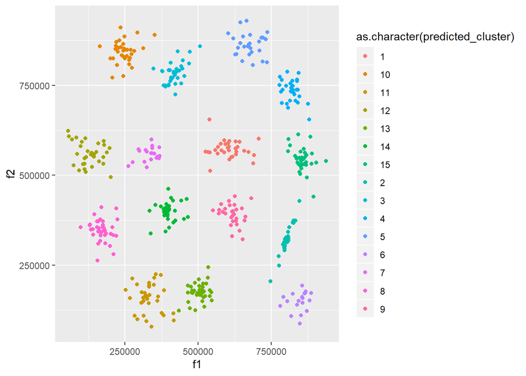

```r
dat.sample.copy <- data.frame(dat.sample)
dat.sample.copy$predicted_cluster <- as.vector(ms$assignment)
ggplot(dat.sample.copy, aes(x = f1, y = f2, label = predicted_cluster)) +
  geom_point(aes(colour = as.character(predicted_cluster)))
```

## Gaussian Mixture

The previous two approaches all behave poorly in the way that overestimates the number of modes in each of dataset. This suggests that many of the modes computed in both way do not correspond to the true modes but just some noise from data. One way to reduce such noise can be increasing the bandwidth. This will generally make the estimated density smoother. Before we do that, we first want to verify that given a smooth estimate, are we going to get the right result?

To do that, assume that we know the groups for each dataset beforehand. Then we fit the gaussian mixture model to data using known group labels as the mixture components. After we have the gaussian mixture estimate, we run the optimization again and see the results.

### **1. Olive Oil**

#### Fit Mixture Model

```r
mix.par.oil <- fit.gmm(oil.data, oil.group.id)
mix.dens.oil <- make.dgmm(mix.par.oil)
```

#### Numerical Optimization On Mixture Model

```r
optim.out.filename <- "/optimizing_result/olive-mixture-density-optima.R"
optim.out.pathname <- paste(dir, optim.out.filename, sep = "\\")
```

```r
control <- control <- list("maxit" = 10000000, "fnscale" = -1e-20)
gradient <- make.dgmm.gradient(mix.par.oil)

optimize.density(oil.data, mix.dens.oil, optim.out.pathname, gradient = gradient, control = control, echo = echo)
```

```r
optima <- read.optim(oil.data, optim.out.pathname)
```

```
## [1] 0
```

#### Cluster Local Maxima

```r
clust <- hclust(dist(optima), method = "ward.D2")
clust$height
```

```
##   [1] 1.629697e-09 2.574372e-09 3.474083e-09 3.590061e-09 3.931336e-09
##   [6] 4.630671e-09 5.732945e-09 5.834931e-09 8.897995e-09 1.154833e-08
##  [11] 1.182505e-08 1.350933e-08 1.441237e-08 1.509117e-08 1.638869e-08
##  [16] 1.673593e-08 1.721334e-08 2.156843e-08 2.364043e-08 2.618326e-08
##  [21] 2.901082e-08 3.257595e-08 3.282729e-08 3.326623e-08 3.399362e-08
##  [26] 3.403715e-08 3.453657e-08 3.919458e-08 3.977317e-08 4.023372e-08
##  [31] 4.037425e-08 4.323517e-08 4.372357e-08 4.760966e-08 5.301925e-08
##  [36] 5.347341e-08 5.442774e-08 6.144492e-08 6.578691e-08 6.929571e-08
##  [41] 7.413237e-08 7.719676e-08 8.164083e-08 8.883140e-08 9.608635e-08
##  [46] 9.624438e-08 9.684489e-08 9.967895e-08 1.053982e-07 1.102555e-07
##  [51] 1.124387e-07 1.186156e-07 1.205785e-07 1.208309e-07 1.235350e-07
##  [56] 1.319945e-07 1.377311e-07 1.396765e-07 1.459968e-07 1.558553e-07
##  [61] 1.566362e-07 1.652029e-07 1.655347e-07 1.718406e-07 1.733042e-07
##  [66] 1.768554e-07 1.789434e-07 1.883495e-07 1.886075e-07 1.924352e-07
##  [71] 1.951254e-07 1.974215e-07 2.007221e-07 2.045877e-07 2.065121e-07
```

[output cut: 100 more lines]

There are 8 “large” merge distances at the end, which suggests that there are 9 groups. This is consistent with what we expect.

```r
estimated.oil.group.id <- cutree(tree = clust, k = 9)
estimated.oil.group.id
```

```
##   [1] 1 1 1 1 1 1 1 1 1 1 1 1 1 1 1 1 1 2 1 1 1 1 1 1 1 2 2 2 2 2 2 2 2 2 2
##  [36] 2 3 2 2 2 2 2 2 2 2 2 2 2 2 2 2 2 2 2 2 2 2 2 2 2 4 2 2 2 2 2 2 2 2 2
##  [71] 2 2 2 2 2 2 2 2 2 2 2 4 2 4 4 4 4 4 4 4 4 4 4 4 4 4 4 4 4 4 4 4 4 4 4
## [106] 4 4 4 4 4 4 4 4 4 4 4 4 4 4 4 2 4 4 4 4 4 4 4 4 4 4 4 4 4 4 4 4 4 4 4
## [141] 4 4 4 4 4 4 4 4 4 4 4 4 4 4 4 4 4 4 4 4 4 4 4 4 4 4 4 4 4 4 4 4 4 4 4
## [176] 4 4 4 4 4 4 4 4 4 4 4 4 4 4 4 4 4 4 4 4 4 4 4 4 4 4 4 4 4 4 4 4 4 4 4
## [211] 4 4 4 4 4 4 4 4 4 4 4 4 4 4 4 4 2 4 4 2 4 4 4 4 4 4 4 4 4 4 4 4 4 4 4
## [246] 4 4 4 4 4 4 4 4 4 4 2 3 3 3 2 2 2 1 3 3 3 1 3 2 3 1 1 2 2 2 4 3 2 3 2
## [281] 2 2 2 3 3 2 1 3 2 3 3 2 3 4 4 4 4 4 4 4 4 4 4 4 4 4 4 4 4 4 4 4 4 4 4
## [316] 4 4 4 4 4 4 4 4 5 5 5 5 5 5 5 5 5 5 5 6 6 6 6 6 6 5 5 5 5 5 5 5 5 5 5
## [351] 5 5 5 5 5 5 5 5 5 5 5 5 5 5 5 5 5 5 5 5 6 6 6 6 6 6 6 6 6 6 6 6 6 6 6
## [386] 5 5 5 5 5 5 5 5 5 5 5 5 5 5 5 5 5 5 5 5 5 5 5 5 6 6 6 6 6 6 6 6 6 6 6
## [421] 6 7 7 7 7 7 7 7 7 7 7 7 7 7 7 7 7 7 7 7 7 7 7 7 7 7 7 7 7 7 7 7 7 7 7
## [456] 7 7 7 7 7 7 7 7 7 7 7 7 7 7 7 7 7 8 8 8 8 8 8 8 8 8 8 8 8 8 8 8 8 8 8
## [491] 8 8 8 8 8 8 8 8 8 8 8 8 8 8 8 8 8 8 8 8 8 8 8 8 8 8 8 8 8 8 8 8 9 9 9
## [526] 9 9 9 9 9 9 9 9 9 9 9 9 9 9 9 9 9 9 9 9 9 9 9 9 9 9 9 9 9 9 9 9 9 9 9
## [561] 9 9 9 9 9 9 9 9 9 9 9 9
```

```r
oil.group.id
```

```
##   [1] 1 1 1 1 1 1 1 1 1 1 1 1 1 1 1 1 1 1 1 1 1 1 1 1 1 2 2 2 2 2 2 2 2 2 2
##  [36] 2 2 2 2 2 2 2 2 2 2 2 2 2 2 2 2 2 2 2 2 2 2 2 2 2 2 2 2 2 2 2 2 2 2 2
##  [71] 2 2 2 2 2 2 2 2 2 2 2 3 3 3 3 3 3 3 3 3 3 3 3 3 3 3 3 3 3 3 3 3 3 3 3
## [106] 3 3 3 3 3 3 3 3 3 3 3 3 3 3 3 3 3 3 3 3 3 3 3 3 3 3 3 3 3 3 3 3 3 3 3
## [141] 3 3 3 3 3 3 3 3 3 3 3 3 3 3 3 3 3 3 3 3 3 3 3 3 3 3 3 3 3 3 3 3 3 3 3
## [176] 3 3 3 3 3 3 3 3 3 3 3 3 3 3 3 3 3 3 3 3 3 3 3 3 3 3 3 3 3 3 3 3 3 3 3
## [211] 3 3 3 3 3 3 3 3 3 3 3 3 3 3 3 3 3 3 3 3 3 3 3 3 3 3 3 3 3 3 3 3 3 3 3
## [246] 3 3 3 3 3 3 3 3 3 3 3 3 4 4 4 4 4 4 4 4 4 4 4 4 4 4 4 4 4 4 4 4 4 4 4
## [281] 4 4 4 4 4 4 4 4 4 4 4 4 4 3 3 3 3 3 3 3 3 3 3 3 3 3 3 3 3 3 3 3 3 3 3
## [316] 3 3 3 3 3 3 3 3 5 5 5 5 5 5 5 5 5 5 5 6 6 6 6 6 6 5 5 5 5 5 5 5 5 5 5
## [351] 5 5 5 5 5 5 5 5 5 5 5 5 5 5 5 5 5 5 5 5 6 6 6 6 6 6 6 6 6 6 6 6 6 6 6
## [386] 5 5 5 5 5 5 5 5 5 5 5 5 5 5 5 5 5 5 5 5 5 5 5 5 6 6 6 6 6 6 6 6 6 6 6
## [421] 6 9 9 9 9 9 9 9 9 9 9 9 9 9 9 9 9 9 9 9 9 9 9 9 9 9 9 9 9 9 9 9 9 9 9
## [456] 9 9 9 9 9 9 9 9 9 9 9 9 9 9 9 9 9 7 7 7 7 7 7 7 7 7 7 7 7 7 7 7 7 7 7
## [491] 7 7 7 7 7 7 7 7 7 7 7 7 7 7 7 7 7 7 7 7 7 7 7 7 7 7 7 7 7 7 7 7 8 8 8
## [526] 8 8 8 8 8 8 8 8 8 8 8 8 8 8 8 8 8 8 8 8 8 8 8 8 8 8 8 8 8 8 8 8 8 8 8
## [561] 8 8 8 8 8 8 8 8 8 8 8 8
```

```r
table(data.frame(true.id = oil.group.id, estimated.id = estimated.oil.group.id))
```

```
##        estimated.id
## true.id   1   2   3   4   5   6   7   8   9
##       1  24   1   0   0   0   0   0   0   0
##       2   0  54   1   1   0   0   0   0   0
##       3   0   5   1 200   0   0   0   0   0
##       4   5  15  15   1   0   0   0   0   0
##       5   0   0   0   0  65   0   0   0   0
##       6   0   0   0   0   0  33   0   0   0
##       7   0   0   0   0   0   0   0  50   0
##       8   0   0   0   0   0   0   0   0  50
##       9   0   0   0   0   0   0  51   0   0
```

```r
rand.index(oil.group.id, cutree(tree = clust, k = 9))
```

```
## [1] 0.9278247
```

### **2. Wine**

#### Fit mixture model

```r
mix.par.wine <- fit.gmm(wine.data, wine.group.id)
mix.dens.wine <- make.dgmm(mix.par.wine)
```

#### Numerical Optimization

```r
optim.out.filename <- "/optimizing_result/wine-mixture-density-optima-fnscale.R"
optim.out.pathname <- paste(dir, optim.out.filename, sep = "\\")
```

```r
control <- list("maxit" = 10000, "fnscale" = -1e-20)

gradient <- make.dgmm.gradient(mix.par.wine)
optimize.density(wine.data, mix.dens.wine, optim.out.pathname, gradient = gradient, control = control)
```

[output not shown]

```r
optima <- read.optim(wine.data, optim.out.pathname)
```

```
## [1] 0
```

#### Cluster Local Maxima

```r
clust <- hclust(dist(optima), method = "ward.D2")
clust$height
```

```
##   [1] 2.475699e-04 2.862055e-04 3.591989e-04 3.826477e-04 4.575249e-04
##   [6] 5.157566e-04 5.548568e-04 6.178709e-04 6.457069e-04 7.322625e-04
##  [11] 8.130181e-04 8.465900e-04 8.520259e-04 8.756037e-04 9.300383e-04
##  [16] 9.377470e-04 1.027120e-03 1.062786e-03 1.176365e-03 1.239741e-03
##  [21] 1.325231e-03 1.354370e-03 1.360268e-03 1.373598e-03 1.457184e-03
##  [26] 1.552239e-03 1.580828e-03 1.591793e-03 1.636627e-03 1.663702e-03
##  [31] 1.707284e-03 1.796497e-03 1.807490e-03 1.921624e-03 2.059866e-03
##  [36] 2.112195e-03 2.117069e-03 2.124748e-03 2.138428e-03 2.174063e-03
##  [41] 2.216696e-03 2.229631e-03 2.233881e-03 2.386424e-03 2.504430e-03
##  [46] 2.581495e-03 2.602823e-03 2.747514e-03 2.804742e-03 2.845864e-03
##  [51] 2.979665e-03 3.356339e-03 3.365605e-03 3.373769e-03 3.421754e-03
##  [56] 3.557481e-03 3.710732e-03 3.775788e-03 3.792816e-03 4.204529e-03
##  [61] 4.212798e-03 4.316278e-03 4.409168e-03 4.482391e-03 4.560833e-03
##  [66] 4.647171e-03 5.041037e-03 5.136268e-03 5.391600e-03 5.551406e-03
##  [71] 5.555329e-03 5.621975e-03 5.891269e-03 6.498257e-03 6.577331e-03
```

[output cut: 21 more lines]

There is a “jump” at the second last merge which suggest that there are 3 groups. This is consistent with what we expect.

```r
estimated.wine.group.id <- cutree(tree = clust, k = 3)
```

```r
table(data.frame(true.id = wine.group.id, estimated.id = estimated.wine.group.id))
```

```
##        estimated.id
## true.id  1  2  3
##       1 59  0  0
##       2  0 70  1
##       3  0  0 48
```

```r
rand.index(wine.group.id, estimated.wine.group.id)
```

```
## [1] 0.9832439
```

### **3. 2d Gaussian Clusters**

#### Fit Mixture Model

```r
mix.par.gaussian.2d <- fit.gmm(gaussian.2d, dat.sample$group_id)
mix.dens.gaussian.2d <- make.dgmm(mix.par.gaussian.2d)
```

#### Numerical Optimization On Mixture Model

```r
optim.out.filename <- "/optimizing_result/gaussian-2d-mixture-density-optima.R"
optim.out.pathname <- paste(dir, optim.out.filename, sep = "\\")
```

```r
control <- control <- list("maxit" = 10000, "fnscale" = -1e-20)
gradient <- make.dgmm.gradient(mix.par.gaussian.2d)

optimize.density(gaussian.2d, mix.dens.gaussian.2d, optim.out.pathname, gradient = gradient, control = control, echo = echo)
```

```r
optima <- read.optim(gaussian.2d, optim.out.pathname)
```

```
## [1] 0
```

#### Cluster Local Maxima

```r
clust <- hclust(dist(optima), method = "ward.D2")
clust$height
```

```
##   [1] 2.689293e-06 2.095666e-05 4.513972e-05 8.325247e-05 9.899050e-05
##   [6] 1.201254e-04 1.257586e-04 1.794760e-04 1.827283e-04 3.035313e-04
##  [11] 3.041657e-04 3.107344e-04 3.209646e-04 3.932660e-04 4.170929e-04
##  [16] 4.200574e-04 5.189377e-04 5.190652e-04 5.333300e-04 5.597726e-04
##  [21] 6.008732e-04 7.598426e-04 7.742109e-04 8.264352e-04 8.429364e-04
##  [26] 9.520483e-04 1.010832e-03 1.050722e-03 1.106505e-03 1.149604e-03
##  [31] 1.162235e-03 1.191355e-03 1.277803e-03 1.287223e-03 1.445398e-03
##  [36] 1.469877e-03 1.489501e-03 1.661313e-03 1.721918e-03 1.737008e-03
##  [41] 1.856095e-03 1.959198e-03 1.963789e-03 1.965477e-03 2.092973e-03
##  [46] 2.106918e-03 2.208595e-03 2.218772e-03 2.541769e-03 2.578034e-03
##  [51] 2.705667e-03 2.749954e-03 2.783974e-03 3.027124e-03 3.043470e-03
##  [56] 3.048947e-03 3.074790e-03 3.078352e-03 3.353821e-03 3.363925e-03
##  [61] 3.530255e-03 3.776533e-03 4.009705e-03 4.391629e-03 4.433707e-03
##  [66] 4.578976e-03 4.601562e-03 4.638892e-03 4.837139e-03 4.888884e-03
##  [71] 5.101904e-03 5.140770e-03 5.230476e-03 5.652850e-03 6.042366e-03
```

[output cut: 85 more lines]

There are 14 “large” merge distances at the end, which suggests that there are 15 groups. This is consistent with what we expect.

```r
estimated.gaussian.2d.group.id <- cutree(tree = clust, k = 15)
```

```r
table(data.frame(true.id = dat.sample$group_id, estimated.id = estimated.gaussian.2d.group.id))
```

```
##        estimated.id
## true.id  1  2  3  4  5  6  7  8  9 10 11 12 13 14 15
##      1  32  0  0  0  0  0  0  0  0  0  0  0  0  0  0
##      2   0 40  0  0  0  0  0  0  0  0  0  0  0  0  0
##      3   0  0 33  0  0  0  0  0  0  0  0  0  0  0  0
##      4   0  0  0 33  1  0  0  0  0  0  0  0  0  0  0
##      5   0  0  0  0  0 19  0  0  0  0  0  0  0  0  0
##      6   0  0  0  0  0  0 20  0  0  0  0  0  0  0  0
##      7   0  0  0  0  0  0  0 38  0  0  0  0  0  0  0
##      8   0  0  0  0  0  0  0  0 29  0  0  0  0  0  0
##      9   0  0  0  0  0  0  0  0  0 36  0  0  0  0  0
##      10  0  0  0  0  0  0  0  0  0  0 35  0  0  0  0
##      11  0  0  0  0  0  0  0  0  0  0  0 38  0  0  0
##      12  0  0  0  0  0  0  0  0  0  0  1  0 40  0  0
##      13  0  0  0  0  0  0  0  0  0  0  0  0  0 39  0
##      14  0  0  0  0  0  0  0  0  0  0  0  0  0  0 39
##      15  0  0  0  0 27  0  0  0  0  0  0  0  0  0  0
```

```r
rand.index(dat.sample$group_id, estimated.gaussian.2d.group.id)
```

```
## [1] 0.9913941
```

## More Experiments on fnscale

We will use the Gaussian mixture model above to test the fnscale. But instead of k mixture components based on k groups, we will use a single mixture component which should only have one mode at its mean. We will use the oil dataset.

```r
same.id <- rep(1, 572)
mix.par.oil <- fit.gmm(oil.data, same.id)
mix.dens.oil <- make.dgmm(mix.par.oil)
```

```r
mix.dens.oil(oil.data) # density values at each data point
```

```
##   [1] 2.956301e-17 2.395140e-17 1.633219e-18 1.665374e-18 6.920233e-19
##   [6] 1.007684e-19 8.989579e-19 8.085150e-18 1.107568e-17 2.515856e-18
##  [11] 3.616338e-19 9.636677e-20 1.042142e-17 5.837570e-19 5.159798e-19
##  [16] 3.271310e-17 2.187868e-19 1.683067e-18 4.960584e-22 2.148540e-18
##  [21] 2.066650e-18 5.317311e-19 2.584012e-19 2.330632e-20 2.144549e-18
##  [26] 1.269299e-16 5.240338e-17 5.182734e-17 2.171187e-17 3.779202e-17
##  [31] 1.214320e-17 2.946668e-18 1.119387e-16 2.024861e-17 6.608340e-17
##  [36] 2.727466e-17 2.169793e-17 3.099733e-17 1.597900e-17 1.483311e-17
##  [41] 8.269634e-17 8.415685e-18 2.827602e-17 7.990173e-18 6.976791e-18
##  [46] 7.648474e-17 5.813434e-17 5.459952e-17 2.186189e-17 5.737128e-20
##  [51] 7.435632e-17 6.637067e-18 4.941106e-17 1.479357e-18 6.523974e-18
##  [56] 2.247366e-17 3.892621e-19 1.652614e-17 9.583040e-18 4.438305e-17
##  [61] 1.196001e-16 1.583815e-19 5.653057e-19 4.349085e-18 9.010713e-17
##  [66] 3.338987e-17 9.947729e-17 1.019695e-16 9.146805e-18 3.666598e-17
##  [71] 8.010865e-18 1.241305e-17 1.897032e-17 3.775911e-17 2.163758e-17
```

[output cut: 100 more lines]

The minimum density values for 572 data points (it is in order of 1e-32)

```r
min(mix.dens.oil(oil.data))
```

```
## [1] 2.088249e-32
```

### Hypothesis

Based on the implementation of optim function, it has a relative tolerance with order 1e-8. It stops the optimization when fabs(f - Fmin) > reltol x (fabs(fmin) + reltol). This means if fabs(f - Fmin) > 1e-8, then it will stop when fabs(f - Fmin) / fabs(fmin) > 1e-8. However, if fabs(f - Fmin) < 1e-8, then reltol dominates fabs(fmin) and criterion no longer works. Therefore, this suggests we need to have all the data points to have orders which are greater than 1e-8.  
Then our hypothesis is: **By rescaling function, we want to make sure all the data points to have orders that are greater the relative tolerance (1e-8). If this is satisfied, the optimization should work properly with no difference.**

### fnscale = -1

```r
optim.out.filename <- "/optimizing_result/olive-unimodal-mixture-density-optima-fnscale=-1.R"
optim.out.pathname <- paste(dir, optim.out.filename, sep = "\\")
```

```r
control <- control <- list("maxit" = 10000000, "fnscale" = -1)
gradient <- make.dgmm.gradient(mix.par.oil)

optimize.density(oil.data, mix.dens.oil, optim.out.pathname, gradient = gradient, control = control, echo = echo)
```

```r
optima <- read.optim(oil.data, optim.out.pathname)
```

```
## [1] 0
```

```r
clust <- hclust(dist(optima), method = "ward.D2")
clust$height
```

```
##   [1]     1.000000     3.741657     3.741657     4.898979     5.567764
##   [6]     6.000000     6.976150     8.306624     8.592633     8.660254
##  [11]     8.944272    10.000000    10.049876    10.890363    10.908712
##  [16]    10.908712    11.416363    13.564660    14.059398    14.177447
##  [21]    14.730920    14.798649    14.832397    15.136050    15.231546
##  [26]    15.556349    16.109004    16.217275    17.320508    17.521415
##  [31]    18.734994    18.734994    18.973666    19.209373    19.697716
##  [36]    20.124612    20.453199    20.542639    20.566964    20.666743
##  [41]    20.712315    21.071308    21.158135    21.213203    21.376890
##  [46]    21.470911    21.610183    21.840330    21.863211    21.886069
##  [51]    22.000000    22.166040    22.248595    22.293497    22.561028
##  [56]    22.752289    23.345235    23.537205    24.090109    24.576411
##  [61]    24.718414    24.859606    24.879711    25.019992    25.166115
##  [66]    25.337719    25.377155    25.632011    25.768197    25.980762
##  [71]    26.076810    26.381812    26.863854    27.531800    27.622455
```

[output cut: 100 more lines]

The merge distances are all large.  
Converged optima:

```r
optima[1:10,]
```

```
##       [,1] [,2] [,3] [,4] [,5] [,6] [,7] [,8]
##  [1,] 1075   75  226 7823  672   36   60   29
##  [2,] 1088   73  224 7709  781   31   61   29
##  [3,]  911   54  246 8113  549   31   63   29
##  [4,]  966   57  240 7952  619   50   78   35
##  [5,] 1051   67  259 7771  672   50   80   46
##  [6,]  911   49  268 7924  678   51   70   44
##  [7,]  922   66  264 7990  618   49   56   29
##  [8,] 1100   61  235 7728  734   39   64   35
##  [9,] 1082   60  239 7745  709   46   83   33
## [10,] 1037   55  213 7944  633   26   52   30
```

Initial location:

```r
oil.data[1:10,]
```

```
##       [,1] [,2] [,3] [,4] [,5] [,6] [,7] [,8]
##  [1,] 1075   75  226 7823  672   36   60   29
##  [2,] 1088   73  224 7709  781   31   61   29
##  [3,]  911   54  246 8113  549   31   63   29
##  [4,]  966   57  240 7952  619   50   78   35
##  [5,] 1051   67  259 7771  672   50   80   46
##  [6,]  911   49  268 7924  678   51   70   44
##  [7,]  922   66  264 7990  618   49   56   29
##  [8,] 1100   61  235 7728  734   39   64   35
##  [9,] 1082   60  239 7745  709   46   83   33
## [10,] 1037   55  213 7944  633   26   52   30
```

True optimum:

```r
colMeans(oil.data)
```

```
## [1] 1231.74126  126.09441  228.86538 7311.74825  980.52797   31.88811
## [7]   58.09790   16.28147
```

It shows that in the original scale there is no optimization performed.

### fnscale = -1e-20

```r
optim.out.filename <- "/optimizing_result/olive-unimodal-mixture-density-optima-fnscale=-1e-20.R"
optim.out.pathname <- paste(dir, optim.out.filename, sep = "\\")
```

```r
control <- control <- list("maxit" = 10000000, "fnscale" = -1e-20)
gradient <- make.dgmm.gradient(mix.par.oil)

optimize.density(oil.data, mix.dens.oil, optim.out.pathname, gradient = gradient, control = control, echo = echo)
```

```r
optima <- read.optim(oil.data, optim.out.pathname)
```

```
## [1] 0
```

```r
clust <- hclust(dist(optima), method = "ward.D2")
clust$height
```

```
##   [1] 3.846272e-07 4.864719e-07 5.887691e-07 8.362806e-07 8.939848e-07
##   [6] 1.093778e-06 1.433485e-06 1.662185e-06 2.123071e-06 2.283134e-06
##  [11] 2.408047e-06 2.659143e-06 2.753432e-06 3.242267e-06 4.669729e-06
##  [16] 5.014357e-06 5.144034e-06 5.293358e-06 5.954968e-06 6.195372e-06
##  [21] 6.714635e-06 6.755377e-06 6.940354e-06 7.042478e-06 7.128977e-06
##  [26] 7.277688e-06 7.281664e-06 7.581973e-06 7.735931e-06 7.767102e-06
##  [31] 7.791485e-06 7.814161e-06 8.093364e-06 8.423570e-06 8.537319e-06
##  [36] 8.699247e-06 8.719743e-06 8.778848e-06 8.788570e-06 9.304565e-06
##  [41] 9.323359e-06 9.353975e-06 9.707211e-06 9.818084e-06 1.032135e-05
##  [46] 1.121416e-05 1.141524e-05 1.217113e-05 1.293268e-05 1.304141e-05
##  [51] 1.330149e-05 1.331525e-05 1.340846e-05 1.392337e-05 1.399242e-05
##  [56] 1.416784e-05 1.522893e-05 1.603590e-05 1.642345e-05 1.688698e-05
##  [61] 1.720610e-05 1.722857e-05 1.731422e-05 1.790020e-05 1.862265e-05
##  [66] 1.871537e-05 1.895616e-05 1.900840e-05 1.933743e-05 2.004949e-05
##  [71] 2.099761e-05 2.117233e-05 2.139197e-05 2.181900e-05 2.241769e-05
```

[output cut: 100 more lines]

Converged optima:

```r
optima[1:10,]
```

```
##           [,1]     [,2]     [,3]     [,4]     [,5]     [,6]     [,7]
##  [1,] 1231.706 126.0872 228.8721 7311.822 980.4940 31.88702 58.09469
##  [2,] 1231.741 126.0944 228.8654 7311.748 980.5280 31.88811 58.09790
##  [3,] 1231.741 126.0944 228.8654 7311.748 980.5279 31.88811 58.09790
##  [4,] 1231.741 126.0944 228.8654 7311.748 980.5280 31.88811 58.09790
##  [5,] 1231.741 126.0944 228.8654 7311.749 980.5275 31.88812 58.09789
##  [6,] 1231.742 126.0944 228.8654 7311.748 980.5271 31.88818 58.09799
##  [7,] 1231.741 126.0944 228.8654 7311.748 980.5279 31.88811 58.09790
##  [8,] 1231.732 126.0911 228.8672 7311.755 980.5276 31.88851 58.09678
##  [9,] 1231.740 126.0940 228.8655 7311.749 980.5290 31.88809 58.09785
## [10,] 1231.757 126.0997 228.8647 7311.699 980.5555 31.88816 58.09879
##           [,8]
##  [1,] 16.28057
##  [2,] 16.28147
##  [3,] 16.28147
##  [4,] 16.28146
##  [5,] 16.28147
##  [6,] 16.28154
##  [7,] 16.28147
##  [8,] 16.28227
##  [9,] 16.28142
## [10,] 16.28202
```

```r
optima[390,]
```

```
## [1] 1145   35  237 7208 1118   20   46    2
```

True optimum:

```r
colMeans(oil.data)
```

```
## [1] 1231.74126  126.09441  228.86538 7311.74825  980.52797   31.88811
## [7]   58.09790   16.28147
```

There is one point that is not at the optimum. If we check location and the density at this point:

```r
oil.data[390,]
```

```
## [1] 1145   35  237 7208 1118   20   46    2
```

```r
mix.dens.oil(oil.data[390,])
```

```
## [1] 2.088249e-32
```

This is indeed the point that has the lowest density with order of 1e-32. Even by rescaling the funtion by 1e-20, it is still at the order of 1e-12 which is within the tolerance 1e-8. Moreover, the converged location is exactly the same as the initial location, which suggests that it is not updated at all. Therefore, this strongly shows that in order for the optimizer to work, every data point must have an order that is greater than 1e-8.

### fnscale = -1e-25

```r
optim.out.filename <- "/optimizing_result/olive-unimodal-mixture-density-optima-fnscale=-1e-25.R"
optim.out.pathname <- paste(dir, optim.out.filename, sep = "\\")
```

```r
control <- control <- list("maxit" = 10000000, "fnscale" = -1e-25)
gradient <- make.dgmm.gradient(mix.par.oil)

optimize.density(oil.data, mix.dens.oil, optim.out.pathname, gradient = gradient, control = control, echo = echo)
```

```r
optima <- read.optim(oil.data, optim.out.pathname)
```

```
## [1] 0
```

```r
clust <- hclust(dist(optima), method = "ward.D2")
clust$height
```

```
##   [1] 1.907496e-08 2.603480e-08 3.001724e-08 3.257264e-08 3.506752e-08
##   [6] 3.691748e-08 4.131809e-08 4.381865e-08 4.643208e-08 4.959165e-08
##  [11] 5.101676e-08 5.185375e-08 5.712777e-08 5.718567e-08 5.944347e-08
##  [16] 6.382713e-08 6.509156e-08 6.541703e-08 6.718114e-08 6.725655e-08
##  [21] 6.794152e-08 6.820263e-08 6.987283e-08 7.292012e-08 7.690550e-08
##  [26] 7.774571e-08 7.783181e-08 7.797022e-08 8.243728e-08 8.373855e-08
##  [31] 8.660788e-08 8.993903e-08 9.707410e-08 9.719169e-08 9.786893e-08
##  [36] 9.975900e-08 1.010203e-07 1.039900e-07 1.040047e-07 1.059312e-07
##  [41] 1.091547e-07 1.094175e-07 1.103580e-07 1.145425e-07 1.155247e-07
##  [46] 1.200968e-07 1.215898e-07 1.276667e-07 1.277309e-07 1.316414e-07
##  [51] 1.326322e-07 1.329347e-07 1.333563e-07 1.366575e-07 1.374023e-07
##  [56] 1.391292e-07 1.449413e-07 1.497687e-07 1.501242e-07 1.519977e-07
##  [61] 1.521242e-07 1.538598e-07 1.539702e-07 1.593301e-07 1.646713e-07
##  [66] 1.733018e-07 1.751415e-07 1.789321e-07 1.805721e-07 1.821422e-07
##  [71] 1.832033e-07 1.842961e-07 1.856333e-07 1.898762e-07 1.925052e-07
```

[output cut: 100 more lines]

Converged optima:

```r
optima[1:10,]
```

```
##           [,1]     [,2]     [,3]     [,4]     [,5]     [,6]     [,7]
##  [1,] 1231.741 126.0944 228.8654 7311.748 980.5280 31.88811 58.09790
##  [2,] 1231.737 126.0951 228.8685 7311.734 980.5420 31.88793 58.09848
##  [3,] 1231.741 126.0944 228.8654 7311.748 980.5280 31.88811 58.09790
##  [4,] 1231.698 126.0795 228.8715 7311.884 980.4471 31.88775 58.09637
##  [5,] 1231.741 126.0944 228.8654 7311.748 980.5279 31.88812 58.09791
##  [6,] 1231.741 126.0944 228.8654 7311.748 980.5280 31.88811 58.09790
##  [7,] 1231.741 126.0944 228.8654 7311.748 980.5280 31.88811 58.09790
##  [8,] 1231.768 126.1040 228.8648 7311.693 980.5490 31.88754 58.09684
##  [9,] 1231.742 126.0949 228.8654 7311.743 980.5320 31.88801 58.09788
## [10,] 1231.741 126.0944 228.8654 7311.748 980.5280 31.88811 58.09789
##           [,8]
##  [1,] 16.28147
##  [2,] 16.28085
##  [3,] 16.28147
##  [4,] 16.28135
##  [5,] 16.28147
##  [6,] 16.28147
##  [7,] 16.28147
##  [8,] 16.28276
##  [9,] 16.28140
## [10,] 16.28146
```

True optimum:

```r
colMeans(oil.data)
```

```
## [1] 1231.74126  126.09441  228.86538 7311.74825  980.52797   31.88811
## [7]   58.09790   16.28147
```

### fnscale = -1e-30

```r
optim.out.filename <- "/optimizing_result/olive-unimodal-mixture-density-optima-fnscale=-1e-30.R"
optim.out.pathname <- paste(dir, optim.out.filename, sep = "\\")
```

```r
control <- control <- list("maxit" = 10000000, "fnscale" = -1e-30)
gradient <- make.dgmm.gradient(mix.par.oil)

optimize.density(oil.data, mix.dens.oil, optim.out.pathname, gradient = gradient, control = control, echo = echo)
```

```r
optima <- read.optim(oil.data, optim.out.pathname)
```

```
## [1] 0
```

```r
clust <- hclust(dist(optima), method = "ward.D2")
clust$height
```

```
##   [1] 5.822114e-08 7.120559e-08 8.537230e-08 8.796169e-08 9.681531e-08
##   [6] 1.172070e-07 1.177190e-07 1.263925e-07 1.290347e-07 1.382146e-07
##  [11] 1.473897e-07 1.497956e-07 1.662539e-07 1.679288e-07 1.683944e-07
##  [16] 1.694649e-07 1.726432e-07 1.734072e-07 1.734987e-07 1.771661e-07
##  [21] 1.776449e-07 1.873801e-07 1.883094e-07 1.886976e-07 1.912551e-07
##  [26] 2.072509e-07 2.083985e-07 2.118214e-07 2.121423e-07 2.166138e-07
##  [31] 2.166538e-07 2.174297e-07 2.340438e-07 2.364736e-07 2.394336e-07
##  [36] 2.397067e-07 2.454874e-07 2.485925e-07 2.506370e-07 2.513696e-07
##  [41] 2.556006e-07 2.688894e-07 2.745670e-07 2.812313e-07 2.832023e-07
##  [46] 2.846386e-07 2.903648e-07 2.923989e-07 2.935303e-07 3.023046e-07
##  [51] 3.045627e-07 3.095664e-07 3.107359e-07 3.164810e-07 3.204105e-07
##  [56] 3.313841e-07 3.330827e-07 3.433448e-07 3.447358e-07 3.660167e-07
##  [61] 3.717723e-07 3.740237e-07 3.775788e-07 3.845363e-07 3.892174e-07
##  [66] 3.895756e-07 3.970782e-07 3.973694e-07 4.045207e-07 4.227758e-07
##  [71] 4.262163e-07 4.357861e-07 4.388305e-07 4.529603e-07 4.534918e-07
```

[output cut: 100 more lines]

Converged optima:

```r
optima[1:10,]
```

```
##           [,1]     [,2]     [,3]     [,4]     [,5]     [,6]     [,7]
##  [1,] 1231.713 126.0857 228.8625 7311.809 980.5215 31.88624 58.09293
##  [2,] 1231.740 126.0937 228.8656 7311.751 980.5259 31.88839 58.09822
##  [3,] 1231.741 126.0944 228.8654 7311.748 980.5280 31.88811 58.09790
##  [4,] 1231.741 126.0944 228.8654 7311.748 980.5280 31.88811 58.09790
##  [5,] 1231.741 126.0944 228.8654 7311.748 980.5280 31.88811 58.09790
##  [6,] 1231.741 126.0944 228.8656 7311.748 980.5282 31.88809 58.09798
##  [7,] 1231.741 126.0944 228.8654 7311.748 980.5280 31.88811 58.09790
##  [8,] 1231.739 126.0979 228.8653 7311.686 980.5936 31.88729 58.09831
##  [9,] 1231.739 126.0941 228.8654 7311.749 980.5305 31.88785 58.09766
## [10,] 1231.741 126.0944 228.8654 7311.748 980.5280 31.88811 58.09790
##           [,8]
##  [1,] 16.27826
##  [2,] 16.28167
##  [3,] 16.28147
##  [4,] 16.28147
##  [5,] 16.28147
##  [6,] 16.28148
##  [7,] 16.28147
##  [8,] 16.28021
##  [9,] 16.28129
## [10,] 16.28147
```

True optimum:

```r
colMeans(oil.data)
```

```
## [1] 1231.74126  126.09441  228.86538 7311.74825  980.52797   31.88811
## [7]   58.09790   16.28147
```

### fnscale = -1e-40

```r
optim.out.filename <- "/optimizing_result/olive-unimodal-mixture-density-optima-fnscale=-1e-40.R"
optim.out.pathname <- paste(dir, optim.out.filename, sep = "\\")
```

```r
control <- control <- list("maxit" = 10000000, "fnscale" = -1e-40)
gradient <- make.dgmm.gradient(mix.par.oil)

optimize.density(oil.data, mix.dens.oil, optim.out.pathname, gradient = gradient, control = control, echo = echo)
```

```r
optima <- read.optim(oil.data, optim.out.pathname)
```

```
## [1] 0
```

```r
clust <- hclust(dist(optima), method = "ward.D2")
clust$height
```

```
##   [1] 0.002392601 0.002421230 0.003035348 0.003167316 0.003264032
##   [6] 0.003349555 0.003544243 0.003546967 0.003597095 0.003656346
##  [11] 0.003758581 0.003882679 0.003927370 0.003949002 0.003979058
##  [16] 0.003982537 0.003998254 0.004013239 0.004093614 0.004125664
##  [21] 0.004388311 0.004401854 0.004426665 0.004431614 0.004432002
##  [26] 0.004457492 0.004555759 0.004728735 0.004733215 0.004737858
##  [31] 0.004756107 0.004866967 0.004913292 0.004920899 0.004946604
##  [36] 0.005007070 0.005113451 0.005116547 0.005183224 0.005192921
##  [41] 0.005199754 0.005256481 0.005269760 0.005299810 0.005303296
##  [46] 0.005313371 0.005346076 0.005348344 0.005396315 0.005422823
##  [51] 0.005463418 0.005473993 0.005479296 0.005500859 0.005525709
##  [56] 0.005546728 0.005567654 0.005575512 0.005639260 0.005659009
##  [61] 0.005784373 0.005843966 0.005867853 0.005873109 0.005876372
##  [66] 0.005900631 0.005911280 0.005916154 0.005923822 0.005930641
##  [71] 0.005944694 0.005953365 0.005965426 0.005967760 0.005983083
```

[output cut: 100 more lines]

```r
optima[1:10,]
```

```
##           [,1]     [,2]     [,3]     [,4]     [,5]     [,6]     [,7]
##  [1,] 1231.756 126.0952 228.8670 7311.761 980.4842 31.89001 58.09919
##  [2,] 1231.727 126.0927 228.8655 7311.781 980.5114 31.88753 58.09863
##  [3,] 1231.705 126.0828 228.8656 7311.831 980.5011 31.88695 58.09572
##  [4,] 1231.714 126.0912 228.8651 7311.770 980.5415 31.88709 58.09785
##  [5,] 1231.749 126.0969 228.8637 7311.754 980.5167 31.88810 58.09723
##  [6,] 1231.732 126.0896 228.8690 7311.804 980.4754 31.88932 58.09956
##  [7,] 1231.789 126.1047 228.8687 7311.676 980.5308 31.89039 58.09976
##  [8,] 1231.719 126.0926 228.8625 7311.758 980.5512 31.88692 58.09664
##  [9,] 1231.831 126.1181 228.8655 7311.560 980.5901 31.89001 58.09967
## [10,] 1231.724 126.0836 228.8674 7311.854 980.4484 31.88865 58.09426
##           [,8]
##  [1,] 16.28574
##  [2,] 16.28139
##  [3,] 16.27927
##  [4,] 16.28038
##  [5,] 16.28197
##  [6,] 16.28241
##  [7,] 16.28439
##  [8,] 16.28044
##  [9,] 16.28555
## [10,] 16.28038
```

True optimum:

```r
colMeans(oil.data)
```

```
## [1] 1231.74126  126.09441  228.86538 7311.74825  980.52797   31.88811
## [7]   58.09790   16.28147
```

Based on the experiment, the result shows that our hypothesis is true. The minimum density value for all the data points is in order of 1e-32. In order to have all the points to have density values greater than 1e-8, we need to at least rescale the functions by 1e-24. In the result, both fnscale = 1 and 1e-20 fails and it shows that for the points that are still below the order of 1e-8, they are not updated at all. With fnscale = 1e-25/1e-30/1e-40, all of the points converge to the same true optimum which is consistent with our hypothesis.